# Data Analysis: CitiBike (2023 - 2025)

The purpose of this section is to analyze (i) demand, (ii) net flow, and (iii) usage patterns of users of CitiBike, to investigate the current situation, how it has changed over time, and where value can be created.

```python
# Imports
import duckdb
import pandas as pd
import matplotlib.pyplot as plt
import matplotlib.dates as mdates
import numpy as np
import seaborn as sns

DATA_PATH = "../data/processed/citibike/*/*/data.parquet"
```

## 1. Demand

Understanding overall demand is essential for identifying seasonal patterns, year-to-year changes, and signs of stagnation. Since demand directly determines revenue and operational needs, analyzing its evolution helps highlight where CitiBike may need targeted interventions.

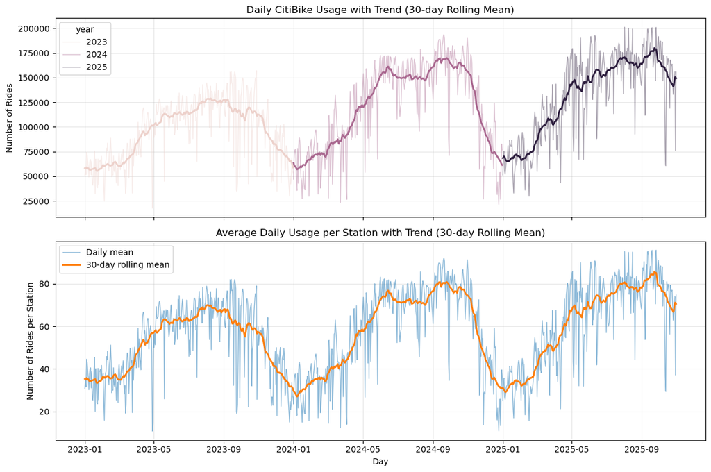

```python
# -------------------------------------------------------------------
# 1. TOP PLOT: Daily CitiBike usage with 30-day rolling mean
# -------------------------------------------------------------------

query_day = f"""
SELECT
    EXTRACT(year FROM started_at) AS year,
    date_trunc('day', started_at)::DATE AS day,
    COUNT(*) AS n_rides
FROM read_parquet('{DATA_PATH}')
WHERE started_at >= '2023-01-01'
GROUP BY year, day
ORDER BY day
"""
df_day = duckdb.query(query_day).df()

df_day = df_day.sort_values("day")
df_day["trend"] = (
    df_day
    .groupby("year")["n_rides"]
    .transform(lambda x: x.rolling(30, center=True, min_periods=1).mean())
)

# -------------------------------------------------------------------
# 2. BOTTOM PLOT: Average daily demand per station (30-day rolling mean)
# -------------------------------------------------------------------

query_daily_station = f"""
SELECT
    date_trunc('day', started_at)::DATE AS day,
    start_station_id,
    COUNT(*) AS n_trips
FROM read_parquet('{DATA_PATH}')
WHERE started_at >= '2023-01-01'
GROUP BY day, start_station_id
ORDER BY day, start_station_id
"""

df_daily_station = duckdb.query(query_daily_station).df()

# Daily mean per station
df_day_stats = (
    df_daily_station
    .groupby("day")["n_trips"]
    .mean()
    .reset_index(name="mean_daily_per_station")
)
df_day_stats = df_day_stats.sort_values("day")

# 30-day rolling mean
df_day_stats["mean_30d"] = (
    df_day_stats["mean_daily_per_station"]
    .rolling(30, center=True, min_periods=1)
    .mean()
)

# -------------------------------------------------------------------
# 3. Combined fig
# -------------------------------------------------------------------

fig, axes = plt.subplots(2, 1, figsize=(12, 8), sharex=True)

# ---- Top plot: daily usage ----
sns.lineplot(
    data=df_day,
    x="day",
    y="n_rides",
    hue="year",
    alpha=0.4,
    linewidth=1,
    ax=axes[0]
)
sns.lineplot(
    data=df_day,
    x="day",
    y="trend",
    hue="year",
    linewidth=2,
    legend=False,
    ax=axes[0]
)

axes[0].set_title("Daily CitiBike Usage with Trend (30-day Rolling Mean)")
axes[0].set_xlabel("")
axes[0].set_ylabel("Number of Rides")
axes[0].grid(alpha=0.3)

# ---- Bottom plot: per-station average demand ----
sns.lineplot(
    data=df_day_stats,
    x="day",
    y="mean_daily_per_station",
    label="Daily mean",
    linewidth=1,
    alpha=0.5,
    ax=axes[1]
)
sns.lineplot(
    data=df_day_stats,
    x="day",
    y="mean_30d",
    label="30-day rolling mean",
    linewidth=2,
    ax=axes[1]
)

axes[1].set_title("Average Daily Usage per Station with Trend (30-day Rolling Mean)")
axes[1].set_xlabel("Day")
axes[1].set_ylabel("Number of Rides per Station")
axes[1].grid(alpha=0.3)

# x-axis date formatting
axes[1].xaxis.set_major_locator(mdates.MonthLocator(interval=4))
axes[1].xaxis.set_major_formatter(mdates.DateFormatter("%Y-%m"))

fig.tight_layout()
fig.savefig("../presentation/assets/img/daily_citibike_usage.png", dpi=300)
plt.show()
```

#### Interpretation

##### Top Panel: Daily CitiBike Usage (30-day Rolling Mean)

- Strong seasonal variation, with high demand in summer and substantial slowdowns in winter.
- Demand increased notably from 2023 to 2024, the increase from 2024 to 2025 is much smaller, indicating a demand growth stagnation.
- Peak summer usage in 2025 is only slightly higher than in 2024, and winter troughs are nearly identical, once more suggesting demand growth stagnation.
- This stagnation highlights the need for actions to boost demand.

##### Bottom Panel: Average Daily Demand per Station (30-day Rolling Mean)

- Same seasonal pattern.
- Per-station usage rises from 2023 to 2024 but shows minimal increase from 2024 to 2025.
- The near-overlap of the 2024 and 2025 curves indicates that increasing the number of bikes or expanding the station network alone may not lead to substantial gains in demand.
- Demand growth flattens: CitiBike enters a mature phase, where additional riders must be gained by lowering barriers to adoption rather than by relying on organic growth.

#### Actionable insight:

1. Winter demand stimulation:
   - targeted promotional campaigns, discounted rides, or seasonal memberships could help smooth the seasonal cycle and increase winter ridership.
2. Boost overall demand by acquiring current non-users:
   - a partnership with an insurance company can mitigate perceived safety risks, one potential barrier to adoption, thereby expanding the user base and increasing demand across all seasons.

## 2. Net flow

Net flow quantifies how many bikes a station gains or loses over time. Persistent imbalances create operational challenges. Analyzing net flow helps identify structural patterns and motivates the development of a predictive model to guide proactive rebalancing and improve system efficiency.

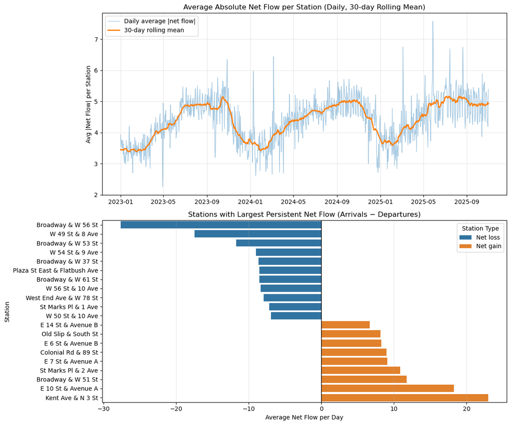

```python
# ------------------------------------------------------------
# 1. Arrivals & departures per station per day
# ------------------------------------------------------------
query_dep = f"""
SELECT
    date_trunc('day', started_at)::DATE AS day,
    start_station_id AS station_id,
    start_station_name AS station_name,
    COUNT(*) AS departures
FROM read_parquet('{DATA_PATH}')
WHERE started_at >= '2023-01-01'
GROUP BY day, station_id, station_name
"""

query_arr = f"""
SELECT
    date_trunc('day', ended_at)::DATE AS day,
    end_station_id AS station_id,
    end_station_name AS station_name,
    COUNT(*) AS arrivals
FROM read_parquet('{DATA_PATH}')
WHERE started_at >= '2023-01-01'
GROUP BY day, station_id, station_name
"""

df_dep = duckdb.query(query_dep).df()
df_arr = duckdb.query(query_arr).df()

# Outer-join, keep one station_name column
df_net = pd.merge(
    df_dep,
    df_arr,
    on=["day", "station_id"],
    how="outer",
    suffixes=("_dep", "_arr")
)

# fill NaNs with 0 and combine names
df_net["departures"] = df_net["departures"].fillna(0)
df_net["arrivals"]   = df_net["arrivals"].fillna(0)
df_net["station_name"] = df_net["station_name_dep"].combine_first(df_net["station_name_arr"])
df_net = df_net[["day", "station_id", "station_name", "departures", "arrivals"]]

# net flow per station/day
df_net["net_flow"] = df_net["arrivals"] - df_net["departures"]

# ------------------------------------------------------------
# 2. TOP PANEL: system-wide avg |net flow| per station (30d roll)
# ------------------------------------------------------------
df_abs = (
    df_net
    .groupby("day")["net_flow"]
    .apply(lambda x: x.abs().mean())
    .reset_index(name="avg_abs_net_flow")
    .sort_values("day")
)

df_abs["avg_abs_net_flow_30d"] = (
    df_abs["avg_abs_net_flow"]
    .rolling(30, center=True, min_periods=1)
    .mean()
)

# ------------------------------------------------------------
# 3. BOTTOM PANEL: station-level persistent net flow
#    (average net flow per day, top 20 by |mean_net_flow|)
# ------------------------------------------------------------
df_station = (
    df_net
    .groupby(["station_id", "station_name"])["net_flow"]
    .mean()
    .reset_index(name="mean_net_flow_per_day")
)

# keep top 20 by absolute imbalance
top_n = 20
df_station["abs_mean"] = df_station["mean_net_flow_per_day"].abs()
df_top = (
    df_station.sort_values("abs_mean", ascending=False)
              .head(top_n)
              .copy()
)

# classify direction for coloring
df_top["direction"] = np.where(df_top["mean_net_flow_per_day"] > 0, "Net gain", "Net loss")

# sort so largest sinks/sources appear at top of the barplot
df_top = df_top.sort_values("mean_net_flow_per_day")

# ------------------------------------------------------------
# 4. Combined fig
# ------------------------------------------------------------
fig, axes = plt.subplots(2, 1, figsize=(12, 10))

# ---- Top: system-wide average |net flow| ----
sns.lineplot(
    data=df_abs,
    x="day",
    y="avg_abs_net_flow",
    linewidth=1,
    alpha=0.4,
    label="Daily average |net flow|",
    ax=axes[0]
)
sns.lineplot(
    data=df_abs,
    x="day",
    y="avg_abs_net_flow_30d",
    linewidth=2,
    label="30-day rolling mean",
    ax=axes[0]
)

axes[0].set_title("Average Absolute Net Flow per Station (Daily, 30-day Rolling Mean)")
axes[0].set_xlabel("")
axes[0].set_ylabel("Avg |Net Flow| per Station")
axes[0].grid(alpha=0.3)
axes[0].legend()

axes[0].xaxis.set_major_locator(mdates.MonthLocator(interval=4))
axes[0].xaxis.set_major_formatter(mdates.DateFormatter("%Y-%m"))

# ---- Bottom: top net-gaining / net-losing stations ----
sns.barplot(
    data=df_top,
    x="mean_net_flow_per_day",
    y="station_name",
    hue="direction",
    ax=axes[1]
)

axes[1].set_title("Stations with Largest Persistent Net Flow (Arrivals − Departures)")
axes[1].set_xlabel("Average Net Flow per Day")
axes[1].set_ylabel("Station")
axes[1].axvline(0, color="black", linewidth=1)
axes[1].grid(axis="x", alpha=0.3)
axes[1].legend(title="Station Type")

fig.tight_layout()
fig.savefig("../presentation/assets/img/net_flow_analysis.png", dpi=300)
plt.show()
```

#### Interpretation:

##### Top panel: Average Absolute Net Flow per Station (Daily, 30-day Rolling Mean):

- The blue/orange curve shows how unbalanced the system is on any given day, averaged across all stations.
- Values rise to 5+ bikes per station in summer and fall below 3.5 bikes per station in winter—indicating strong seasonal imbalance patterns.
- These patterns repeat consistently in 2023, 2024, and 2025, suggesting predictable cyclical dynamics.
- Short-term spikes reflect operational shocks (weather events, surge usage, outages), illustrating that the imbalance can change rapidly.
- Higher average |net flow| means CitiBike must redistribute more bikes, increasing truck miles, labor costs, and risk of station outages.
- The long-run stability of the rolling mean shows that imbalance is structural and recurring, not random.

#### Actionable insight: Build a model that can predict net flow

1. Net flow is a major operational pain point
   - High |net flow| requires extensive rebalancing operations.
   - Predicting net flow lets CitiBike deploy rebalancing resources more efficiently.
2. The imbalance is predictable
   - Strong seasonality (high in summer, low in winter).
   - Station-level patterns are persistent across years.
     - A model can learn these patterns and forecast future imbalances.
3. Modeling net flow at the station level enables:
   - targeted redistribution
   - pre-emptive rebalancing
4. Forecasting net flow reduces service disruptions
   - Stations running empty → lost rides → lost revenue.
   - Stations filling up → blocked docks → customer insatifaction.
   - Predicting these events in advance improves overall service reliability.

## 3. Usage patterns

Understanding how usage varies across weekdays, weekends, and hours of the day is critical for operational planning. These temporal patterns determine when rebalancing, repairs, and servicing should occur, and which rider groups are active at different times. This section explores how consistent and predictable these patterns are

### 3.1 Bike vs. E-Bike

Comparing usage patterns between classic bikes and e-bikes helps clarify how riders use different vehicle types.

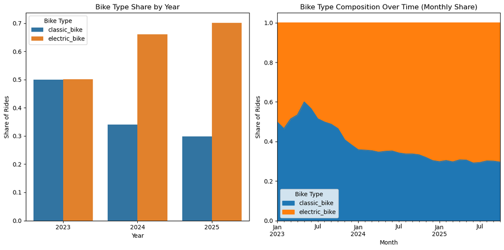

```python
query = f"""
WITH data AS (
    SELECT
        started_at,
        rideable_type
    FROM read_parquet('{DATA_PATH}')
    WHERE started_at >= '2023-01-01'
)

-- Yearly aggregation
SELECT
    'year' AS level,
    date_trunc('year', started_at) AS t,
    rideable_type,
    COUNT(*) AS n_rides
FROM data
GROUP BY level, t, rideable_type

UNION ALL

-- Monthly aggregation
SELECT
    'month' AS level,
    date_trunc('month', started_at) AS t,
    rideable_type,
    COUNT(*) AS n_rides
FROM data
GROUP BY level, t, rideable_type

ORDER BY level, t, rideable_type
"""

df = duckdb.query(query).df()

# ---------- 2. Split into yearly + monthly and compute percentages ----------

df_year  = df[df["level"] == "year"].copy()
df_month = df[df["level"] == "month"].copy()

df_year["year"] = pd.to_datetime(df_year["t"]).dt.year
df_month["month"] = pd.to_datetime(df_month["t"])

df_year["pct"]  = df_year["n_rides"] / df_year.groupby("year")["n_rides"].transform("sum")
df_month["pct"] = df_month["n_rides"] / df_month.groupby("month")["n_rides"].transform("sum")

# Pivot for area chart: one column per bike type
df_pivot = df_month.pivot(index="month", columns="rideable_type", values="pct").sort_index()

# ---------- 3. Side-by-side plots ----------

fig, axes = plt.subplots(1, 2, figsize=(12, 6))

# Left: Yearly barplot (share of rides by bike type)
sns.barplot(
    data=df_year,
    x="year",
    y="pct",
    hue="rideable_type",
    ax=axes[0]
)
axes[0].set_title("Bike Type Share by Year")
axes[0].set_xlabel("Year")
axes[0].set_ylabel("Share of Rides")
axes[0].legend(title="Bike Type")

# Right: Monthly stacked area (composition over time)
df_pivot.plot.area(ax=axes[1])
axes[1].set_title("Bike Type Composition Over Time (Monthly Share)")
axes[1].set_xlabel("Month")
axes[1].set_ylabel("Share of Rides")
axes[1].legend(title="Bike Type")

fig.tight_layout()
fig.savefig("../presentation/assets/img/bike_type_share.png", dpi=300)
plt.show()
```

#### Interpretation:

##### Right panel: Bike Type Composition Over Time (Monthly Share):

- Bike-type usage is stable across seasons: the share of e-bike vs classic bike usage does not materially shift during winter.
- The absence of seasonal switching indicates that classic-bike users rarely upgrade to e-bikes even in adverse conditions.
- E-bike share increases observed system-wide are therefore not driven by winter substitution, but instead by long-run structural adoption.
- The stability of the composition reinforces the earlier insight: the growth in e-bike share is flattening.

#### Actionable insights

- CitiBike has likely reached the natural equilibrium between classic-bike and e-bike users. Attempting to shift users across bike types is unnecessary and unlikely to yield meaningful gains.

### 3.2 Member vs. Casual

Understanding differences between member and casual usage is crucial for CitiBike’s business model. This comparison helps identify core users versus occasional riders, and informs strategies related to membership offerings, pricing, and potential demand interventions targeted at each group.

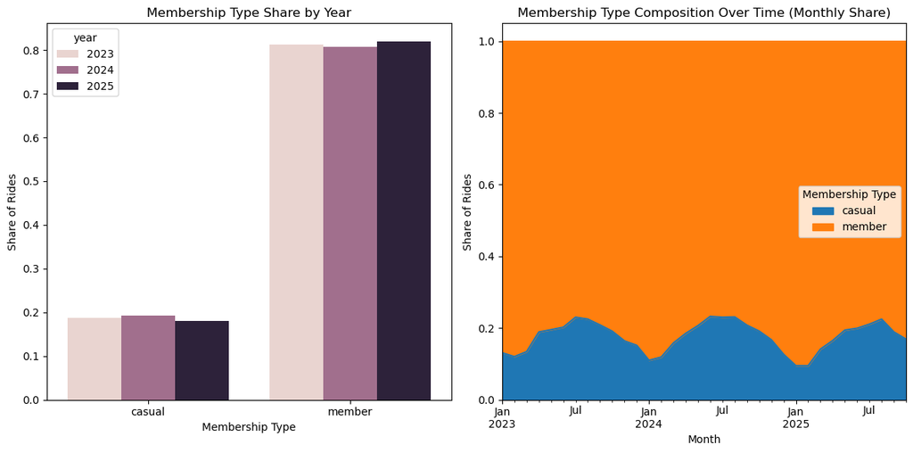

```python
query = f"""
WITH data AS (
    SELECT
        started_at,
        member_casual
    FROM read_parquet('{DATA_PATH}')
    WHERE started_at >= '2023-01-01'
)

-- Yearly aggregation
SELECT
    'year' AS level,
    date_trunc('year', started_at) AS t,
    member_casual,
    COUNT(*) AS n_rides
FROM data
GROUP BY level, t, member_casual

UNION ALL

-- Monthly aggregation
SELECT
    'month' AS level,
    date_trunc('month', started_at) AS t,
    member_casual,
    COUNT(*) AS n_rides
FROM data
GROUP BY level, t, member_casual

ORDER BY level, t, member_casual
"""
df = duckdb.query(query).df()

import matplotlib.pyplot as plt
import seaborn as sns

# Split
df_year  = df[df["level"] == "year"].copy()
df_month = df[df["level"] == "month"].copy()

# Make nice columns
df_year["year"] = pd.to_datetime(df_year["t"]).dt.year
df_month["month"] = pd.to_datetime(df_month["t"])

# Percentages
df_year["pct"]  = df_year["n_rides"] / df_year.groupby("year")["n_rides"].transform("sum")
df_month["pct"] = df_month["n_rides"] / df_month.groupby("month")["n_rides"].transform("sum")

# Pivot for area chart
df_pivot = df_month.pivot(index="month", columns="member_casual", values="pct").sort_index()

fig, axes = plt.subplots(1, 2, figsize=(12, 6))

# Left: Yearly barplot
sns.barplot(
    data=df_year,
    x="member_casual",
    y="pct",
    hue="year",
    ax=axes[0]
)
axes[0].set_title("Membership Type Share by Year")
axes[0].set_xlabel("Membership Type")
axes[0].set_ylabel("Share of Rides")
#axes[0].yaxis.set_major_formatter(plt.matplotlib.ticker.PercentFormatter(1.0))

# Right: Monthly stacked area chart
df_pivot.plot.area(ax=axes[1])
axes[1].set_title("Membership Type Composition Over Time (Monthly Share)")
axes[1].set_xlabel("Month")
axes[1].set_ylabel("Share of Rides")
#axes[1].yaxis.set_major_formatter(plt.matplotlib.ticker.PercentFormatter(1.0))
axes[1].legend(title="Membership Type")

fig.tight_layout()
fig.savefig("../presentation/assets/img/membership_type_share.png", dpi=300)
plt.show()
```

#### Interpretation:

##### Left panel: Membership Type Share by Year:

- The share of rides taken by members is very high and remarkably stable across years (≈ 80–82%).
- The share of casual riders fluctuates slightly (≈ 18–20%), but there is no meaningful upward or downward trend between 2023 and 2025.
- This stability indicates that CitiBike’s customer base consists of two persistent segments:
  - a large, loyal group of members
  - a smaller, consistent group of casual riders
- The lack of year-to-year variation suggests CitiBike has reached a natural equilibrium in the member vs. casual composition under current conditions.

##### Right panel: Membership Type Composition Over Time (Monthly Share):

- There is a clear seasonal pattern in casual ridership:
  - casual share rises in late spring and summer (peak at ~22–24%)
  - casual share drops sharply in winter (~10–12%)
- Seasonal variation aligns well with expectations:
  - members ride consistently year-round
  - casual riders are more sensitive to weather and tourism patterns
- Despite these seasonal fluctuations, the year-round average composition does not change, reinforcing that the member vs. casual ratio is structurally stable.

#### Actionable insights: Converting causal users to members through promotional activities and advertising

- Members seem to more consistently use the service in winter months.
- Hence, by converting causal users to members, we might observe an increase in the low-demand winter months.
- This could be done by increasing promotional activities and advertising in winter months.

### 3.3 Usage by Weekday

Understanding how rides are distributed across weekdays and weekends helps distinguish commuter-driven demand from leisure-oriented usage. This split is important for deciding when to prioritize bike availability, when to schedule larger rebalancing and repairs, and when targeted promotions (e.g., weekend campaigns) are likely to be most effective.

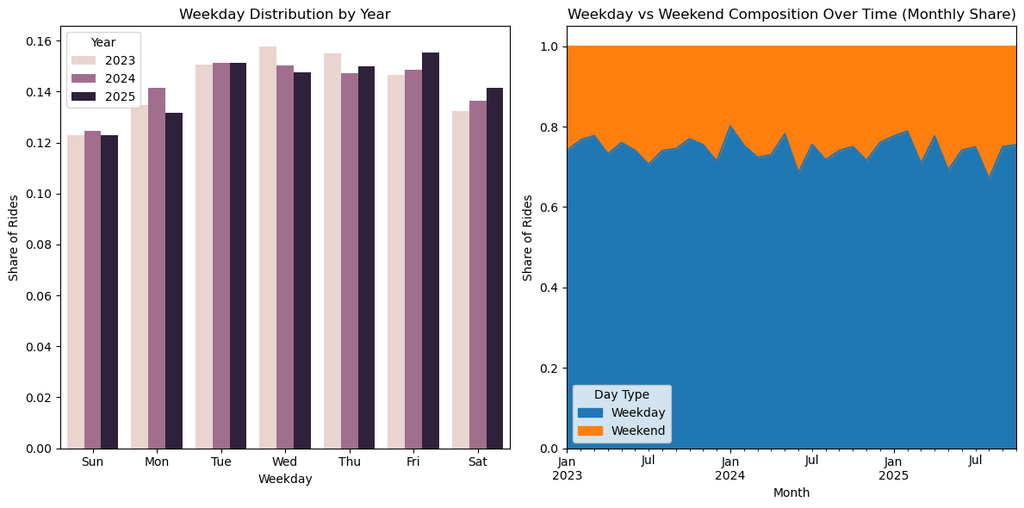

```python
weekday_names = ["Sun", "Mon", "Tue", "Wed", "Thu", "Fri", "Sat"]

# -------------------------------------------------------------------
# 1. One query: yearly + monthly weekday counts
# -------------------------------------------------------------------
query = f"""
WITH data AS (
    SELECT
        started_at,
        EXTRACT(dow FROM started_at) AS weekday
    FROM read_parquet('{DATA_PATH}')
    WHERE started_at >= '2023-01-01'
)

-- Yearly aggregation
SELECT
    'year' AS level,
    date_trunc('year', started_at)::DATE AS t,
    weekday,
    COUNT(*) AS n_rides
FROM data
GROUP BY level, t, weekday

UNION ALL

-- Monthly aggregation
SELECT
    'month' AS level,
    date_trunc('month', started_at)::DATE AS t,
    weekday,
    COUNT(*) AS n_rides
FROM data
GROUP BY level, t, weekday

ORDER BY level, t, weekday
"""

df = duckdb.query(query).df()

# -------------------------------------------------------------------
# 2. Split into yearly + monthly, add labels, compute percentages
# -------------------------------------------------------------------
# Year-level
df_year = df[df["level"] == "year"].copy()
df_year["year"] = pd.to_datetime(df_year["t"]).dt.year
df_year["weekday_name"] = df_year["weekday"].astype(int).map(lambda x: weekday_names[x])
df_year["pct"] = df_year["n_rides"] / df_year.groupby("year")["n_rides"].transform("sum")

# Month-level
df_month = df[df["level"] == "month"].copy()
df_month["month"] = pd.to_datetime(df_month["t"])
df_month["weekday_name"] = df_month["weekday"].astype(int).map(lambda x: weekday_names[x])
df_month["pct"] = df_month["n_rides"] / df_month.groupby("month")["n_rides"].transform("sum")

# -------------------------------------------------------------------
# 3. Build Weekday vs Weekend monthly shares
# -------------------------------------------------------------------
def day_type(w):
    return "Weekend" if w in ["Sat", "Sun"] else "Weekday"

df_ww = df_month.copy()
df_ww["day_type"] = df_ww["weekday_name"].map(day_type)

# Sum weekday/weekend within each month
df_ww = (
    df_ww.groupby(["month", "day_type"], as_index=False)["pct"]
         .sum()
         .sort_values("month")
)

# Pivot to wide format for stacked area chart
df_ww_pivot = (
    df_ww.pivot(index="month", columns="day_type", values="pct")
         .sort_index()
)

# -------------------------------------------------------------------
# 4. Combined 2×1 plot
# -------------------------------------------------------------------
fig, axes = plt.subplots(1, 2, figsize=(12, 6))

# ---- Left: Weekday distribution by year ----
sns.barplot(
    data=df_year,
    x="weekday_name",
    y="pct",
    hue="year",
    ax=axes[0]
)
axes[0].set_title("Weekday Distribution by Year")
axes[0].set_xlabel("Weekday")
axes[0].set_ylabel("Share of Rides")
#axes[0].yaxis.set_major_formatter(mtick.PercentFormatter(1.0))
axes[0].legend(title="Year")

# ---- Right: Weekday vs Weekend composition over time (stacked area) ----
df_ww_pivot.plot.area(ax=axes[1])

axes[1].set_title("Weekday vs Weekend Composition Over Time (Monthly Share)")
axes[1].set_xlabel("Month")
axes[1].set_ylabel("Share of Rides")
#axes[1].yaxis.set_major_formatter(mtick.PercentFormatter(1.0))
axes[1].legend(title="Day Type")

fig.tight_layout()
fig.savefig("../presentation/assets/img/weekday_vs_weekend_share.png", dpi=300)
plt.show()
```

#### Interpretation:

##### Right panel: Weekday vs Weekend Composition Over Time (Monthly Share):

- Across months, weekday rides consistently make up ~72–78% of total usage, while weekend rides account for ~22–28%.
- This weekday–weekend split shows very limited seasonal variation, indicating that user behavior remains similar across the year.
- Even during winter months (when overall demand drops), the relative share of weekday and weekend rides stays stable — weekday commuting remains the dominant use case.
- This stability implies that the CitiBike system is used primarily as a weekday transport service, with weekend usage playing a supporting, but not growing, role.

#### Actionable insights:

1. Focus growth strategies on weekday commuting rather than weekend leisure.
   - The dominant and stable usage pattern is weekday commuting.
   - Therefore, interventions that support commuting — such as employer partnerships, transit integration, or improved station availability during peak hours — will have the highest impact.
2. Larger rebalancing and bike repairs in weekends.
   - As majority usage takes place in weekdays, larger weekly rebalancing should take place on weekends, preferably sundays.
   - More severe repairs should take place on weekends, preferably sundays.
3. Targeted actions to increase winter demand should focus on commuters, not leisure riders.
   - Winter demand drops substantially, but the weekday/weekend composition remains stable.
   - This means weekday commuters also ride less in winter, not just casual weekend users.
   - Strategies could include:
     - winter ride incentives
     - bundled monthly passes
     - employer co-financing for winter months
     - insurance-backed safety messaging

### 3.4 Usage by Hour of Day

Hourly patterns show when demand peaks and when the system is least used. These insights help determine optimal windows for rebalancing, maintenance, and bike redistribution, as well as ensuring bike availability during critical peak hours

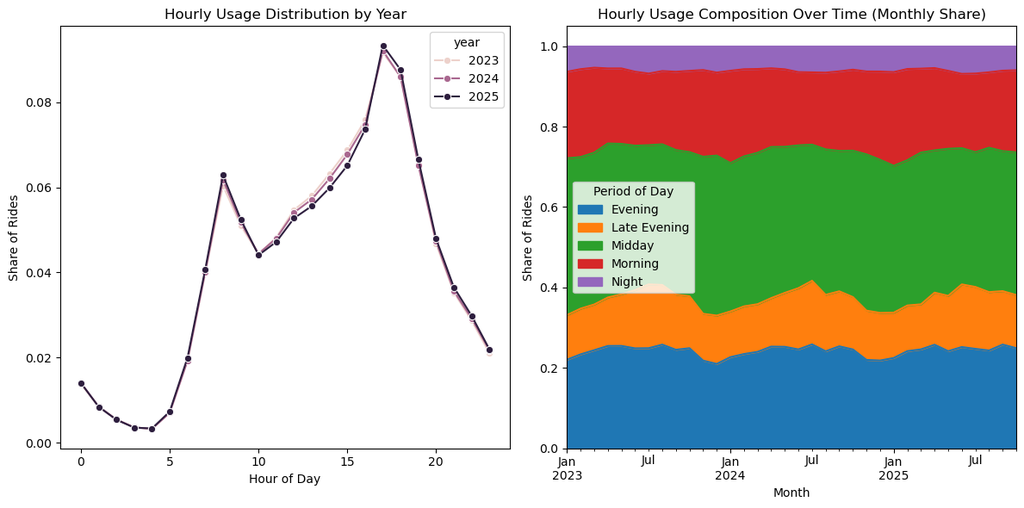

```python
# ------------------------------------------------------------
# 1. Query: yearly + monthly hour-of-day distributions
# ------------------------------------------------------------
query = f"""
WITH data AS (
    SELECT
        started_at,
        EXTRACT(hour FROM started_at) AS hour
    FROM read_parquet('{DATA_PATH}')
    WHERE started_at >= '2023-01-01'
)

-- Yearly aggregation
SELECT
    'year' AS level,
    date_trunc('year', started_at)::DATE AS t,
    hour,
    COUNT(*) AS n_rides
FROM data
GROUP BY level, t, hour

UNION ALL

-- Monthly aggregation
SELECT
    'month' AS level,
    date_trunc('month', started_at)::DATE AS t,
    hour,
    COUNT(*) AS n_rides
FROM data
GROUP BY level, t, hour

ORDER BY level, t, hour
"""

df = duckdb.query(query).df()

# ------------------------------------------------------------
# 2. Split + percentages
# ------------------------------------------------------------

# Year-level
df_year = df[df["level"] == "year"].copy()
df_year["year"] = pd.to_datetime(df_year["t"]).dt.year
df_year["pct"] = df_year["n_rides"] / df_year.groupby("year")["n_rides"].transform("sum")

# Month-level
df_month = df[df["level"] == "month"].copy()
df_month["month"] = pd.to_datetime(df_month["t"])
df_month["pct"] = df_month["n_rides"] / df_month.groupby("month")["n_rides"].transform("sum")

# ------------------------------------------------------------
# 3. Group hours into bins for the stacked-area plot
# ------------------------------------------------------------
def hour_bin(h):
    if 7 <= h <= 10:
        return "Morning"
    elif 11 <= h <= 16:
        return "Midday"
    elif 17 <= h <= 19:
        return "Evening"
    elif 20 <= h <= 23:
        return "Late Evening"
    else:
        return "Night"

df_month["hour_bin"] = df_month["hour"].astype(int).map(hour_bin)

df_bins = (
    df_month.groupby(["month", "hour_bin"], as_index=False)["pct"]
            .sum()
            .sort_values("month")
)

df_pivot = df_bins.pivot(index="month", columns="hour_bin", values="pct").sort_index()

# ------------------------------------------------------------
# 4. Plot
# ------------------------------------------------------------
fig, axes = plt.subplots(1, 2, figsize=(12, 6))

# Left: Hour distribution by year
sns.lineplot(
    data=df_year,
    x="hour",
    y="pct",
    hue="year",
    marker="o",
    ax=axes[0]
)
axes[0].set_title("Hourly Usage Distribution by Year")
axes[0].set_xlabel("Hour of Day")
axes[0].set_ylabel("Share of Rides")

# Right: Hour-of-day composition over time (stacked-area)
df_pivot.plot.area(ax=axes[1])
axes[1].set_title("Hourly Usage Composition Over Time (Monthly Share)")
axes[1].set_xlabel("Month")
axes[1].set_ylabel("Share of Rides")
axes[1].legend(title="Period of Day")

fig.tight_layout()
fig.savefig("../presentation/assets/img/hourly_usage_share.png", dpi=300)
plt.show()
```

#### Interpretation:

##### Left panel: Hourly Usage Distribution by Year:

- The shape of hourly usage is stable across 2023–2025, indicating consistent behavioral patterns.
- CitiBike usage is very low overnight (0–5), with a small rise in early morning (6–7).
- There is a clear morning peak around 8–9, consistent with commuting behavior.
- Usage increases gradually through the day and reaches the strongest peak around 17–18, reflecting the evening commute.
- After 19:00, usage declines sharply, with limited evening leisure activity relative to commuting.
- Year-to-year differences are minimal: CitiBike’s commuting-centric usage profile is persistent and stable.

##### Right panel: Hourly Usage Composition Over Time (Monthly Share):

- Across all months and years, midday (11–16) accounts for the largest share of total rides, representing a broad base of short trips, errands, and leisure rides.
- Evening peak (17–19) and morning peak (7–10) together make up a significant portion (~40%).
- Seasonal fluctuations are visible but modest:
  - Evening peak share increases in summer months, likely due to longer daylight hours and higher leisure activity.
  - Nighttime and late-evening shares expand slightly in summer and contract in winter.
- The relative shares remain stable over the time, indicating a predictable temporal usage pattern.

#### Actionable insights:

1. Strengthen service for commute-heavy hours (7–10 & 16–19)
   - Since commuting hours consistently account for the largest spikes in usage, CitiBike should prioritize:
   - high bike availability in the morning at residential stations
   - high dock availability in business districts
   - targeted rebalancing before and after peak windows
   - This improves user satisfaction for CitiBike’s highest-value, most time-sensitive riders.
2. Predictability enables precise operational planning
   - Because hourly usage patterns are stable across months and years, CitiBike can:
   - optimize rebalancing schedules
   - plan maintenance windows during low-demand overnight hours

### 3.5 Duration and distance per usage

Trip durations and distances provide insights into how users engage with the system—whether the service is mainly used for short hops or longer trips. These distributions guide decisions on optimal bike vs. e-bike fleet composition and help quantify risk exposure for potential insurance partnerships.

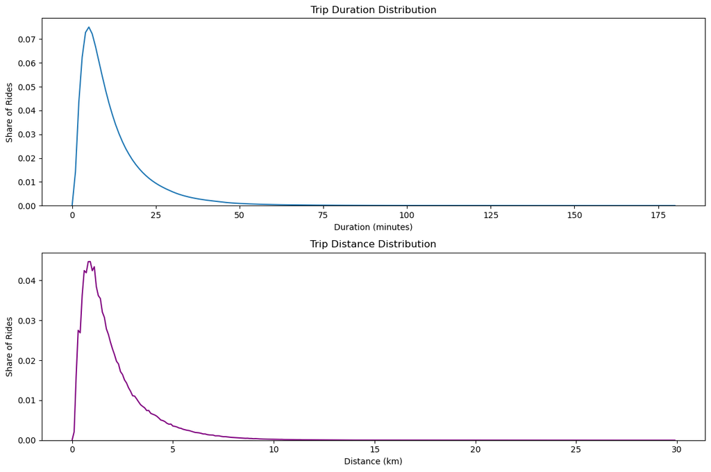

```python
# ------------------------------------------------------------
# 1. Duration distribution (binned at 1-minute resolution)
# ------------------------------------------------------------
query_duration = f"""
WITH dur AS (
    SELECT
        date_diff('minute', started_at, ended_at) AS duration_min
    FROM read_parquet('{DATA_PATH}')
    WHERE started_at >= '2023-01-01'
)
SELECT
    duration_min,
    COUNT(*) AS n_trips
FROM dur
WHERE duration_min BETWEEN 0 AND 180   -- 0–3 hours
GROUP BY duration_min
ORDER BY duration_min;
"""

df_dur = duckdb.query(query_duration).df()

query_distance = f"""
WITH pairs AS (
    SELECT
        start_station_id,
        end_station_id,
        ANY_VALUE(start_lat) AS lat1,
        ANY_VALUE(start_lng) AS lon1,
        ANY_VALUE(end_lat)   AS lat2,
        ANY_VALUE(end_lng)  AS lon2,
        COUNT(*) AS n_trips
    FROM read_parquet('{DATA_PATH}')
    WHERE started_at >= '2023-01-01'
      AND start_station_id IS NOT NULL
      AND end_station_id   IS NOT NULL
    GROUP BY start_station_id, end_station_id
),
pairs_dist AS (
    SELECT
        *,
        2 * 6371 * ASIN(
            SQRT(
                POWER(SIN(RADIANS(lat2 - lat1) / 2), 2) +
                COS(RADIANS(lat1)) * COS(RADIANS(lat2)) *
                POWER(SIN(RADIANS(lon2 - lon1) / 2), 2)
            )
        ) AS dist_km
    FROM pairs
),
bins AS (
    SELECT
        ROUND(dist_km::NUMERIC, 1) AS dist_bin,
        SUM(n_trips) AS n_trips
    FROM pairs_dist
    WHERE dist_km > 0 AND dist_km < 30    -- no artificial cap; 30km filters absurd GPS errors
    GROUP BY 1
)
SELECT * FROM bins ORDER BY dist_bin;
"""

df_dist = duckdb.query(query_distance).df()


# -------------------------------------------------------
# Convert counts to freq
# -------------------------------------------------------
df_dur["rel_freq"]  = df_dur["n_trips"] / df_dur["n_trips"].sum()
df_dist["rel_freq"] = df_dist["n_trips"] / df_dist["n_trips"].sum()

# -------------------------------------------------------
# 2×1 PLOT
# -------------------------------------------------------
fig, axes = plt.subplots(2, 1, figsize=(12, 8), sharex=False)

# ---- Panel 1: Duration ----
sns.lineplot(
    data=df_dur,
    x="duration_min",
    y="rel_freq",
    ax=axes[0]
)
axes[0].set_title("Trip Duration Distribution")
axes[0].set_xlabel("Duration (minutes)")
axes[0].set_ylabel("Share of Rides")
axes[0].set_ylim(bottom=0)

# ---- Panel 2: Distance ----
sns.lineplot(
    data=df_dist,
    x="dist_bin",
    y="rel_freq",
    ax=axes[1],
    color="purple"
)
axes[1].set_title("Trip Distance Distribution")
axes[1].set_xlabel("Distance (km)")
axes[1].set_ylabel("Share of Rides")
axes[1].set_ylim(bottom=0)

fig.tight_layout()
fig.savefig("../presentation/assets/img/duration_distance_distribution.png", dpi=300)
plt.show()
```

#### Actionable insights:

1. Fleet Composition (E-bike vs Classic)
   - Because most trips are short, classic bikes remain highly effective.
   - E-bikes are likely most valuable for:
     - the right tail of the distribution (3–10 km trips), and
     - neighborhoods with greater hills or longer travel corridors.
     - Fleet allocation can be optimized: more e-bikes where longer distances cluster, classic bikes elsewhere.
2. Insurance Partnership Implications
   - These plots are informative to insurers:
     - Short, predictable trips → low risk exposure
     - Very small share of long-distance rides → low tail risk

## 4. Conclusion

The analysis reveals clear and consistent patterns across CitiBike usage that inform strategic opportunities for increasing demand, improving operations, and enabling value-creating partnerships.

### 1. Demand Patterns → Increase Winter Demand & Acquire New Users

Daily ridership and station-level demand show strong seasonality and a clear slowdown in year-over-year growth, indicating that CitiBike is approaching a mature adoption phase. This stagnation underscores two needs:

1. targeted winter promotional activities to stimulate off-season ridership, and
2. partnerships with an insurance provider to reduce perceived safety risks and attract risk-averse non-users, thereby expanding overall demand.

### 2. Net Flow Patterns → Need for a Prediction Model

Station-level net flow exhibits persistent imbalances—some stations consistently lose bikes while others consistently gain them. These stable structural patterns motivate building a predictive net-flow model to support rebalancing, improve fleet distribution, and reduce operational inefficiencies.

### 3. Hourly & Weekly Usage Patterns → Optimized Rebalancing & Targeted Interventions

Hourly and weekday usage patterns are highly regular, with predictable commuter peaks and stable weekday/weekend splits. These insights indicate when major rebalancing, maintenance, and repairs should be scheduled to minimize disruption. They also help refine which user segments and time windows should be targeted with demand interventions or incentives.

### 4. Duration & Distance Patterns → Fleet Optimization & Insurance-Relevant Risk Profiling

Trip durations and distances are tightly concentrated in short urban trips, reinforcing CitiBike’s role as a last-mile mobility system. These patterns inform the optimal fleet composition—classic bikes for dense, short-trip zones and e-bikes for longer corridors—and demonstrate a low, predictable risk profile suitable for embedded micro-insurance offerings.